# RepData_PeerAssessment_1

avneesh90

Sunday, October 19, 2014

**Show any code that is needed to**

```
1. Load the data (i.e. read.csv() )
```

```r
## read file
x=read.csv("activity.csv")
```

2. Process/transform the data (if necessary) into a format suitable for your analysis

```r
## change to date data type
x[,2]=as.Date(as.character(x[,2]))
```

**What is mean total number of steps taken per day?**

For this part of the assignment, you can ignore the missing values in the dataset.

```
1. Make a histogram of the total number of steps taken each day
```

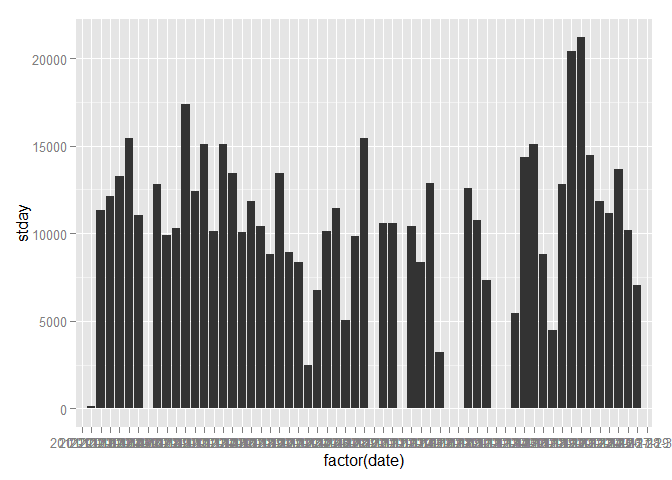

```
2. Calculate and report the mean and median total number of steps taken per day
```

```r
library(plyr)
library(ggplot2)

z1= ddply(x,"date", summarise, stday=sum(steps))
ggplot(z1,aes(x=factor(date), y=stday)) + geom_bar(stat="identity")
```

```r
##mean
mean(z1[,2],na.rm=TRUE)
```

```
## [1] 10766.19
```

```r
## median
median(z1[,2],na.rm=TRUE)
```

```
## [1] 10765
```

**What is the average daily activity pattern?**

```
1. Make a time series plot (i.e. type = "l") of the 5-minute interval (x-axis) and the average number of steps taken, averaged across all days (y-axis)
```

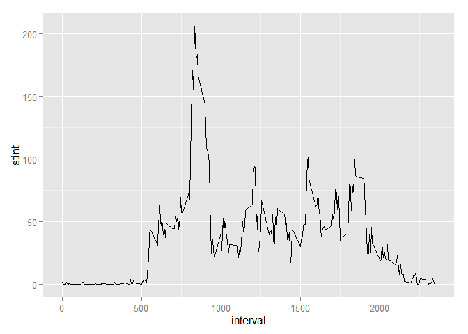

```
2. Which 5-minute interval, on average across all the days in the dataset, contains the maximum number of steps
```

```r
z2= ddply(x,"interval", summarise, stint=mean(steps,na.rm=TRUE))
ggplot(z2,aes(x=interval, y=stint)) + geom_line()
```

```r
##interval containing max steps in ainterval
z2[which.max(z2[,2]),1]
```

```
## [1] 835
```

**Inputing missing values**

Note that there are a number of days/intervals where there are missing values (coded as NA). The presence of missing days may introduce bias into some calculations or summaries of the data.

```
1. Calculate and report the total number of missing values in the dataset (i.e. the total number of rows with NAs)
```

```r
##no of missing values
sum(is.na(x[,1]))
```

```
## [1] 2304
```

2. Devise a strategy for filling in all of the missing values in the dataset. The strategy does not need to be sophisticated. For example, you could use the mean/median for that day, or the mean for that 5-minute interval, etc. *using the mean for that five min interval for missing values*
3. Create a new dataset that is equal to the original dataset but with the missing data filled in.

```r
# z3 new data set containing missing values
z3=x
for (i in 1:17568){
  if(is.na(z3[i,1]))  {
    z3[i,1]<-z2[(if(i%%288) i%%288 else 288), 2]
  }
}
```

[output not shown]

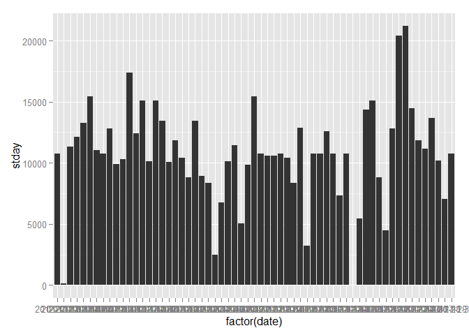

```r
z4= ddply(z3,"date", summarise, stday=sum(steps))
ggplot(z4,aes(x=factor(date), y=stday)) + geom_bar(stat="identity")
```

```r
##mean
mean(z4[,2],na.rm=TRUE)
```

```
## [1] 10766.19
```

```r
## median
median(z4[,2],na.rm=TRUE)
```

```
## [1] 10766.19
```

-*Mean remains the same as mean values were used for missing values* -*Median value has changed now to one of the values missing earlier and hence is same as mean*

**Are there differences in activity patterns between weekdays and weekends?**

For this part the weekdays() function may be of some help here. Use the dataset with the filled-in missing values for this part.

```
1. Create a new factor variable in the dataset with two levels -- "weekday" and "weekend" indicating whether a given date is a weekday or weekend day.
```

```r
z3$weekday= "weekday"
for(i in 1:17568){
  if(weekdays(z3[i,2])=="Saturday" || weekdays(z3[i,2])=="Sunday" ) z3[i,4]="weekend"
}
z3$weekday=as.factor(z3$weekday)
```

```
2. Make a panel plot containing a time series plot (i.e. type = "l") of the 5-minute interval (x-axis) and the average number of steps taken, averaged across all weekday days or weekend days (y-axis). The plot should look something like the following, which was created using simulated data:
```

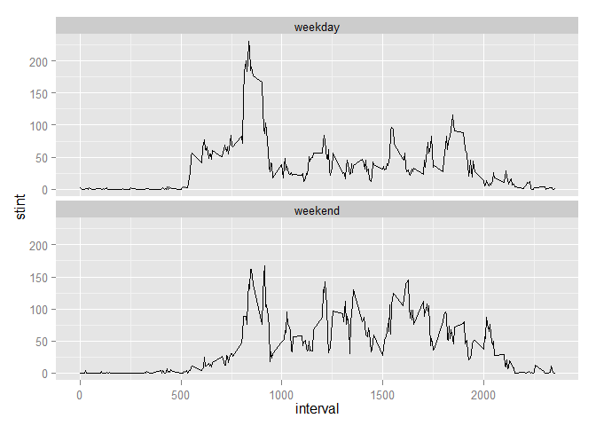

```r
z5= ddply(z3,c("weekday","interval"), summarise, stint=mean(steps,na.rm=TRUE))

ggplot(z5, aes(x=interval,y=stint)) + facet_wrap("weekday",nrow=2) + geom_line()
```